# Analysis of US Immigration Policy Impact: 2004–2024

Group Athens - DATA 2401

2025-05-04

## Introduction

Our analysis centers around the defining feature of American life by exploring immigration trends in the United States using data collected by U.S. Customs and Border Protection’s (CBP) Office of Field Operations from 2004 to 2024 provided by the U.S. Office of Homeland Security Statistics. How does U.S. Immigration policy impact CPB Encounters?

Our approach overlays important U.S. Immigration policy events onto an exploratory analysis of CBP Encounter data from 2004 to 2024 to look for trends or inflection points in the data compared to U.S. policy enactments. The data collected by CBP is provided in annual and monthly formats which we explore. Our analysis uses RStudio for data cleaning, data analysis and visualization on the source data directly without manual operations so the analysis is fully reproducible. Comparing changes in CBP Encounters relative to U.S. Immigration policy may help inform on the merit or effectiveness of future immigration policy.

## Data Preparation & Display

The CBP Encounters Key Homeland Security Metric (KHSM) includes any encounter of a removable alien. This includes three sets of data:

- People who unlawfully crossed the border between ports of entry.
- People who entered at a port of entry but are inadmissible.
- People expelled under the Title 42 public health order between March 2020 and May 2023 due to COVID-19

Source: [CBP Encounters - Key Homeland Security Metric](https://ohss.dhs.gov/sites/default/files/2025-01/KHSM%20Encounters%20%28OFO%29%20fy25m11.xlsx)

CBP Encounters data provided by Office of Homeland Security Statistics’ begins in 2004 and data collection is on going. Given the project scope and data continuing to be collected, our first step in preparing the data is to filter the data for analysis to only years for which are fully covered in our dataset so 2025 is excluded from our analysis. We load the data directly in the source Microsoft Excel format using the *readxl* library for R. Our analysis starts with three initial steps outlined below:

1. Filter data to years between and including 2004 and 2024
2. Sanitize and rename column headers to a more sensible nomenclature
3. Summarize and/or segregate data in order to visualize for exploration

We focus our exploration on the following tabular datasets bundled in the data source: **Annual Region**, **Annual Citizenship**, **Annual Family Status**, **Annual Rgn EnfAdm Fam Status**

From the above mentioned tables we look at *Fiscal Year*, which we name to **Year**. We look at *Quantity* which we rename to **Encounters**. We rename *Citizenship* to **Origin** and *Family Status* to **Family**. We also use **Region** without renaming.

## Exploratory Data Analysis

### Annual Region Encounters

Our analysis starts with CBP Encounters by Annual Region. We overlay six U.S Immigration policy events corresponding to the year enacted. We see a steep increase in CBP Encounters in 2021 particularly at *Southwest Land Border* and *Air Ports of Entry/Interior* which seemed like an interesting data trend as it coincided directly to the ending of the U.S. Immigration policy of *Migrant Protection Protocol* also known as **Remain in Mexico**. Let’s explore more.

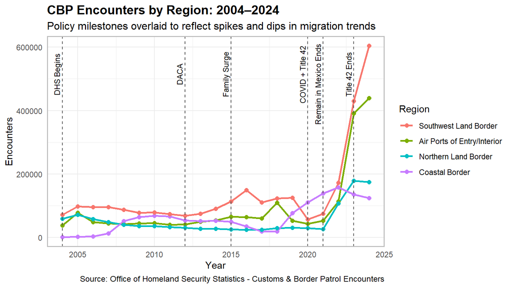

### Annual Citizenship (Origin) Encounters

Our next analysis was of the Annual Citizenship dataset which we refer to as Annual Origin. We could not directly visualize all encounters by all countries of origin so we first summarized and counted all encounters by Origin which we then used to select the top five countries by encounter quantity. We used this result to directly then filter on a new summary by gathering the top five origins and summarize the result by Origin and Year and found total encounters by Origin and Year. We find another interesting uptick in encounters around the time when Remain in Mexico ended and of the top five countries of origin, the bottom two which did not spike seem to coincide with the Annual Region Encounters above. Phillipines and Canada both seem like countries of origin that would not be affected by Remain in Mexico and the data trends as such. Let’s next look at types of encounters by family status.

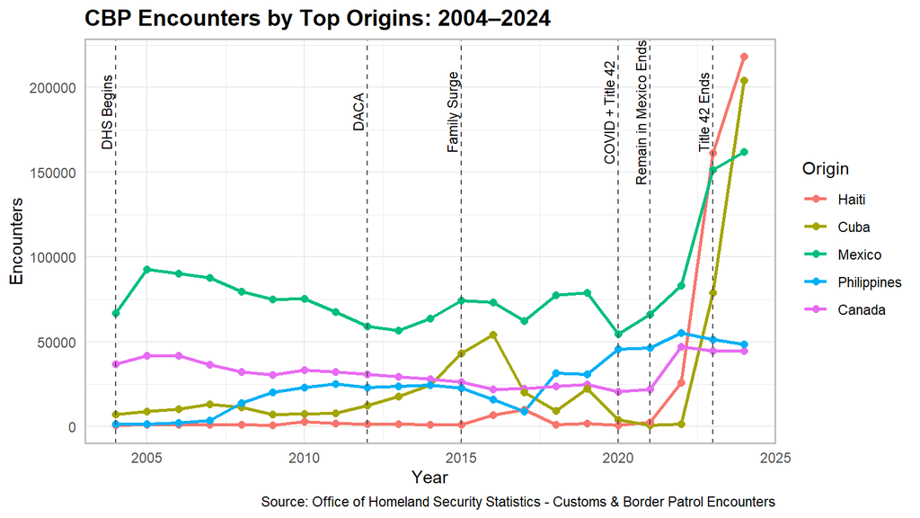

### Annual Encounters by Family Status

Our analysis turns to Annual Family Status dataset which we summarize by Year and Family status to find total encounters by these categories. We see again the uptick coinciding with the ending of the Remain in Mexico policy but this time we see also an uptick in the proportion of encounters of Family Unit Individuals. This uptick does not seem evidently related to ending of Remain in Mexico.

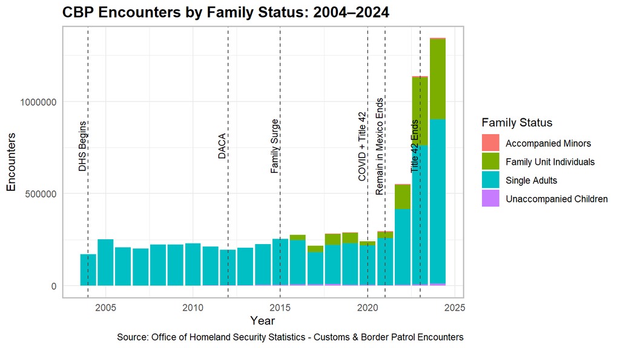

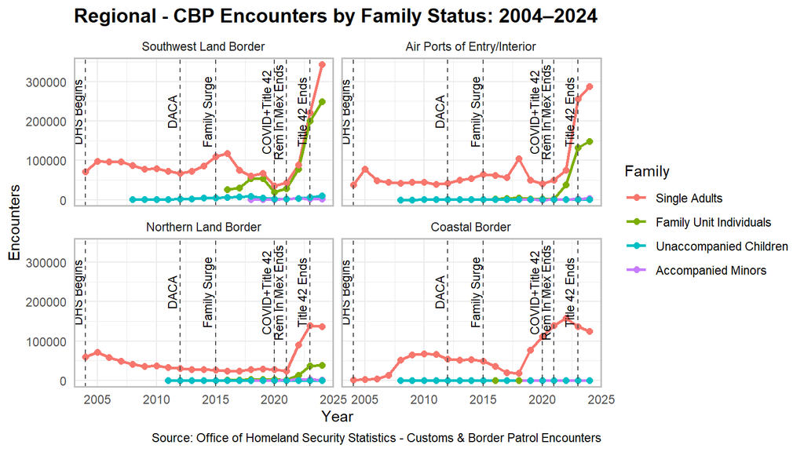

We also looked at Monthly CBP Encounter data but did not seem to find evidence that either supports or rejects the idea that ending Remain in Mexico contributed to an in increase in CBP Encounters.

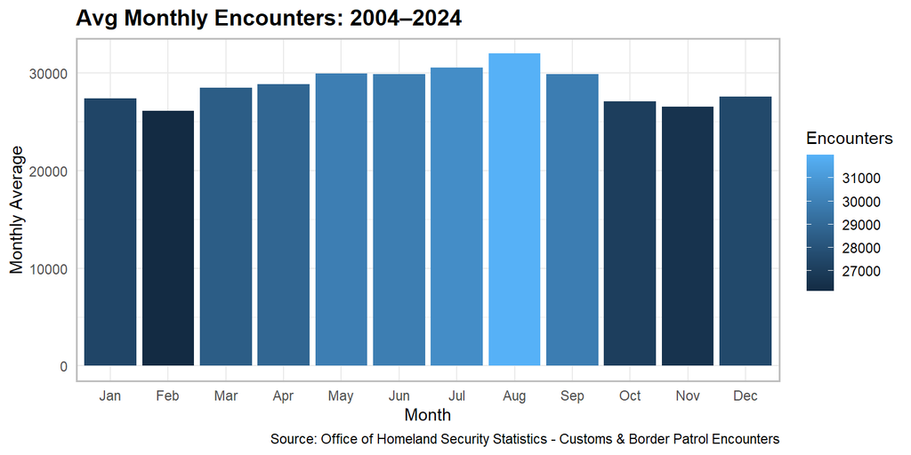